# GSE155423 alt PCA ARNAQ Report

2024-10-31

*Version: 0.1*

# 1 Project Summary

| Summary | Value |
| --- | --- |
| Samples | 24 |
| Genome | GRCm39.112 |
| Genes | 37005 |
| Detected genes | 26011 |

# 2 Assignment Summary

Reads may not be assigned to features for one of a number of reasons. Exact categories depend on the input data, but common categories are:

- **Ambiguity**: The read maps, but overlaps multiple features.
- **MultiMapping**: The read maps to multiple locations in the transcriptome so cannot be assigned uniquely. Note that such reads are double-counted (or more) so a large number may exaggerate the total number of reads.
- **NoFeatures**: The read maps, but does not overlap any defined features.
- **Unmapped**: The read does not map well.

Additionally, If ERCC spike-ins are present, they are considered separately from the requested feature set (which are typically Ensembl genes).

## 2.1 Count

Absolute read counts.

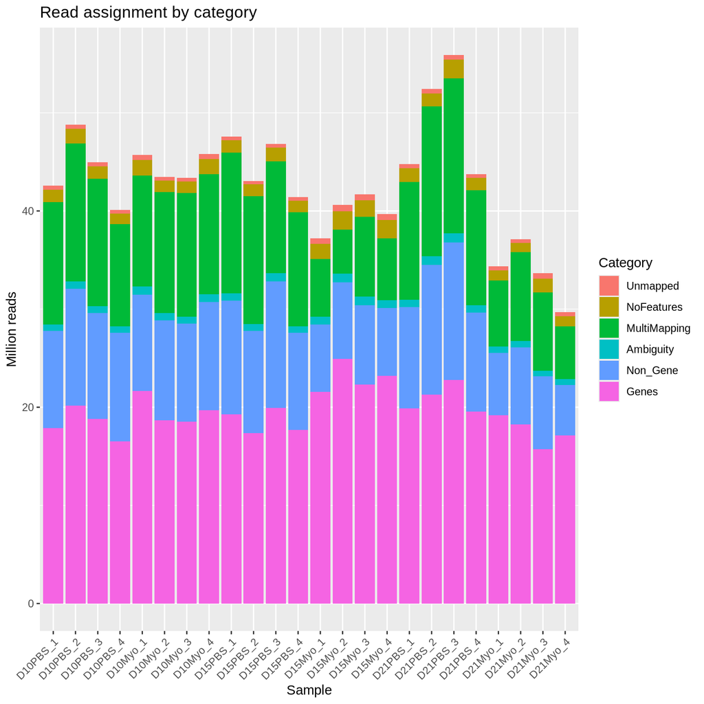

## 2.2 Proportion

The same counts, as a proportion of the total.

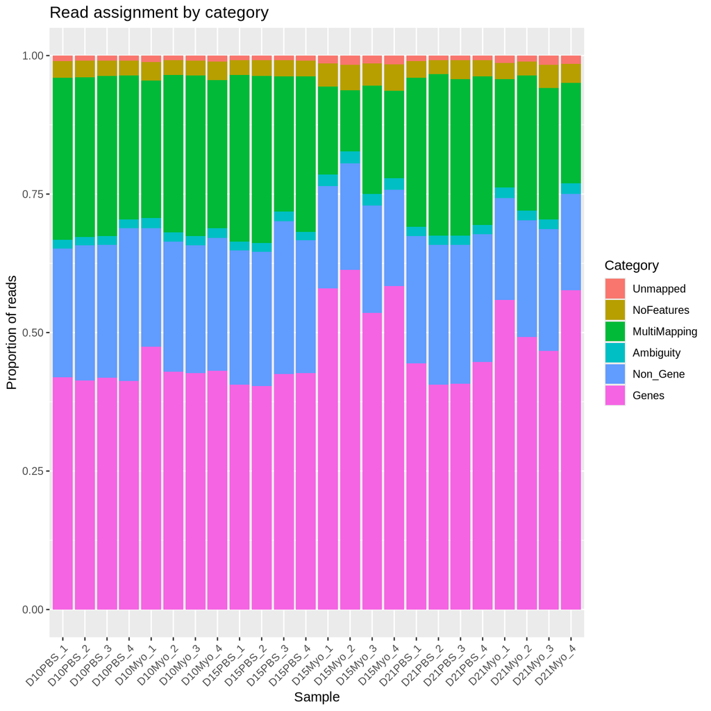

# 3 Library Complexity

Poor-quality samples often have a smaller number of genes represented than the rest, or a disproportionately large number of reads mapping to only a subset of genes.

## 3.1 Diversity of Reads

These curves show how many of the total reads map to the most-expressed genes for each sample. Samples that start at a high value, or follow a markedly different curve to the rest, are likely to be unreliable.

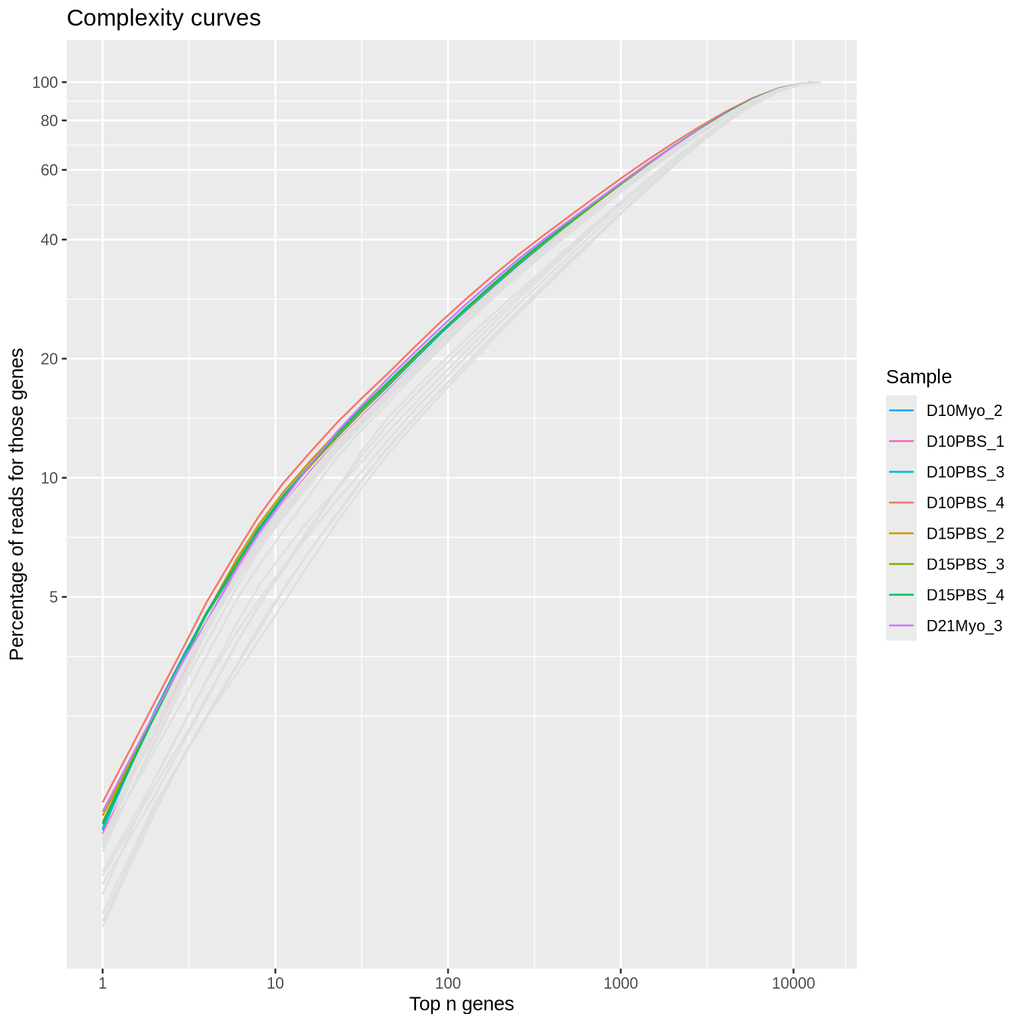

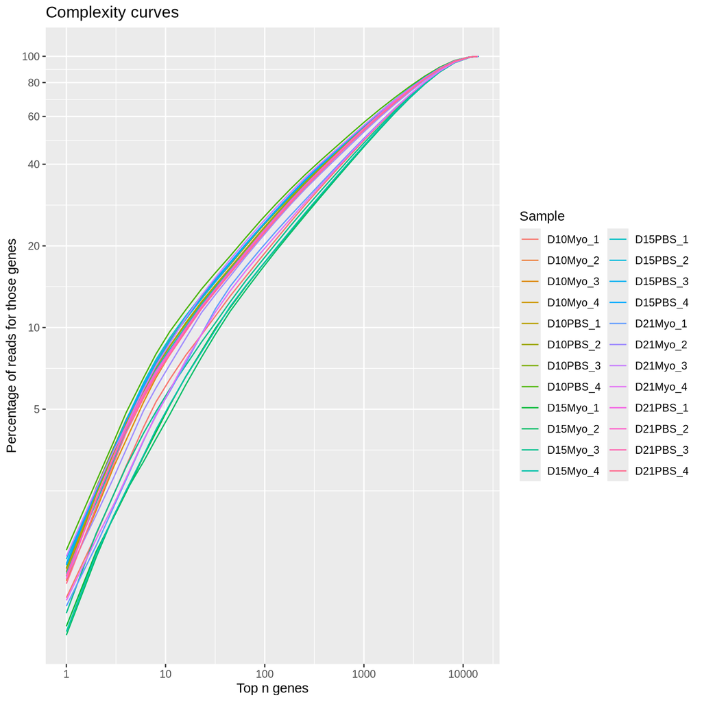

## 3.2 Detected Genes

These curves show the total number of detected genes for each sample, as the number varies with counts-per-million thresholds.

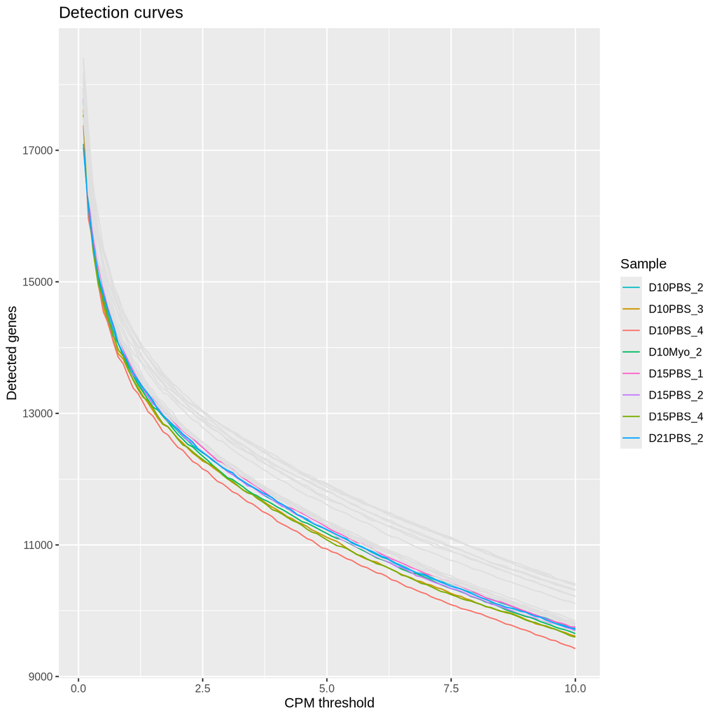

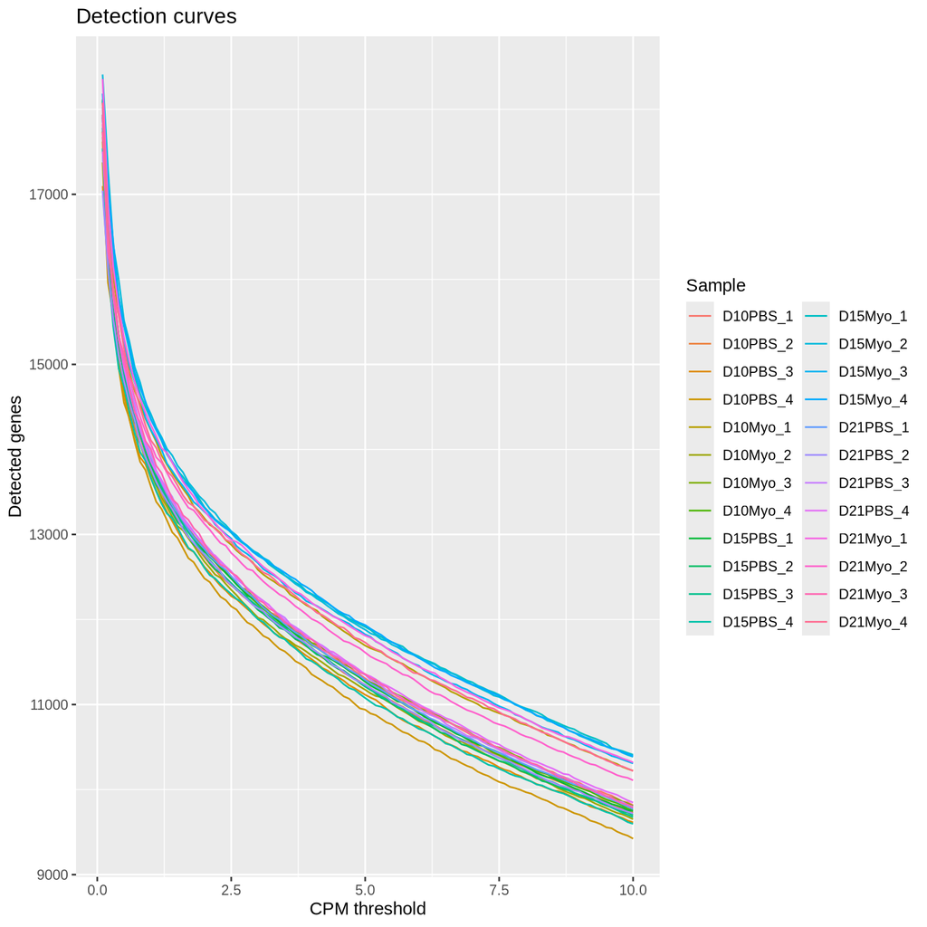

# 4 Ensembl Biotype Breakdown

Ensembl provides a mapping of genes to [biotypes](https://www.ensembl.org/info/genome/genebuild/biotypes.html). This can be used to determine if any unwanted categories are over-represented in the samples. Biotypes have been collapsed into a smaller number of categories here to aid clarity.

## 4.1 By Sample

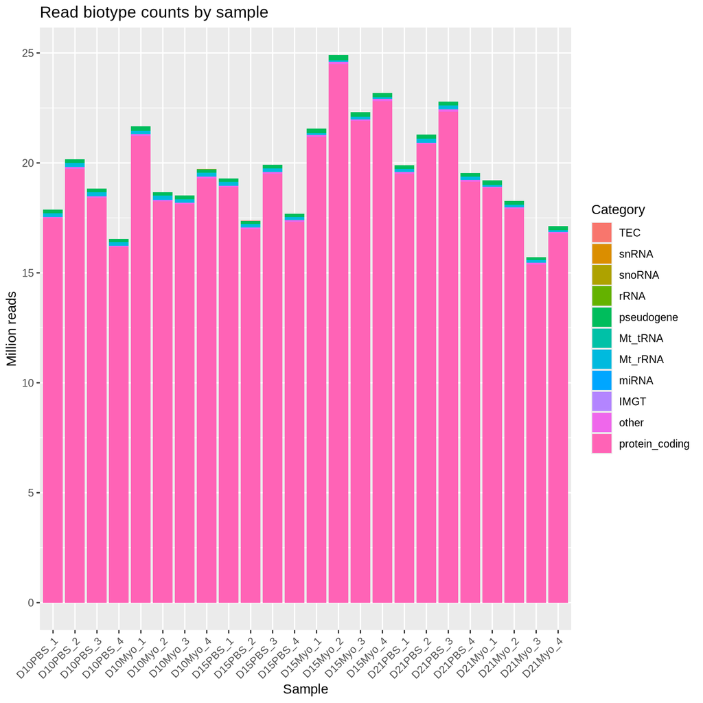

## 4.2 Any Detected Gene

This chart shows how many different genes are detected across the project in each of the biotype categories.

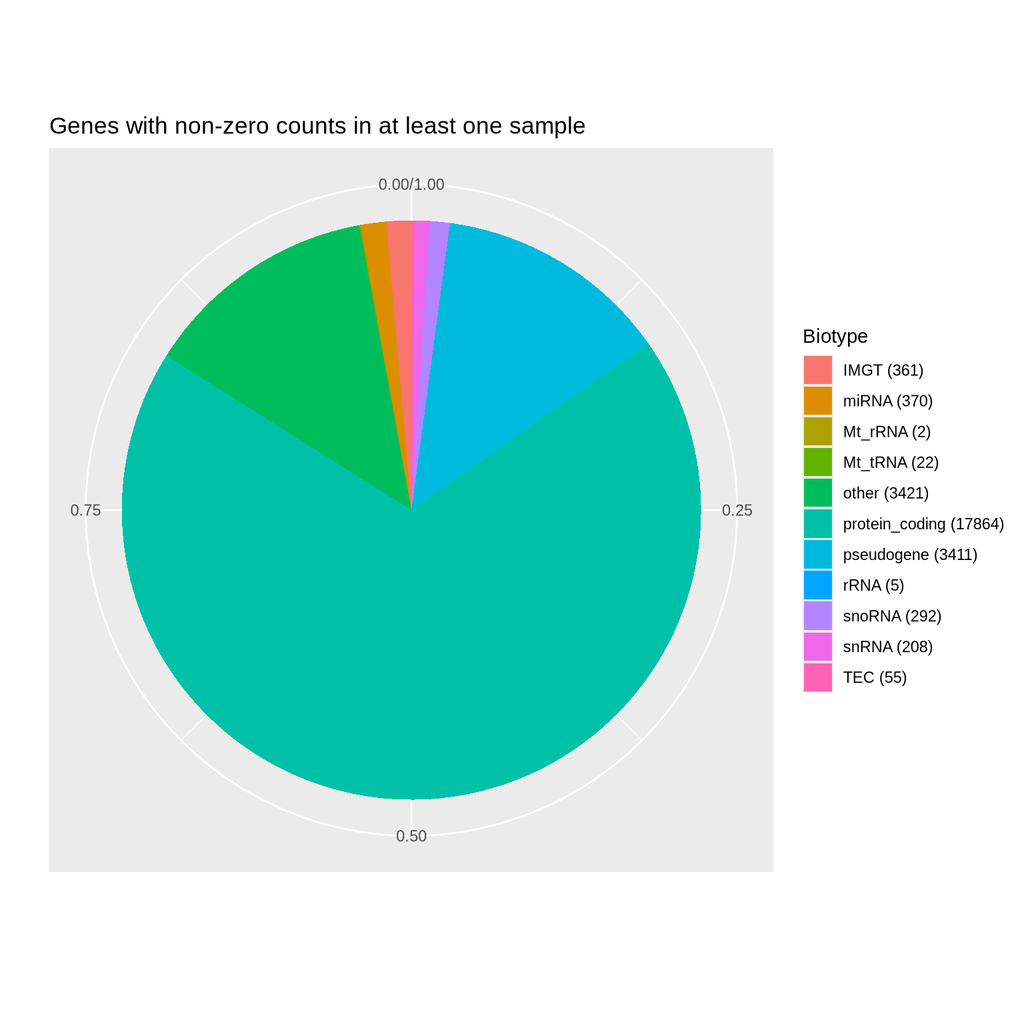

# 5 Normalisation Performance

For the following plots, the gene counts are normalised using a variance-stabilising technique[^1] In some projects, with poor-quality data, the normalisation is less effective than is ideal. The ideal result is for the red trend line to be close to horizontal. For projects where it is not, the rest of the QC may not be reliable.

Each cell is coloured depending on how many genes fall within it.

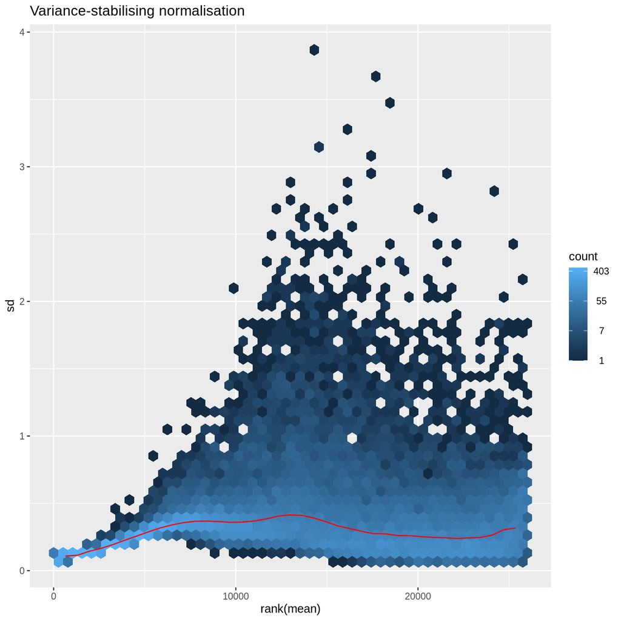

# 6 Hierarchical Clustering

Inter-sample similarity can be used to confirm that different experimental groups for clusters in the data. It can also reveal unexpected features, such as batch effects, that may need to be adjusted for in downstream analysis.

Two methods of measuring this similarity are given here: Euclidean distance and Spearman’s Rank correlation. The former is more sensitive to outlier samples but typically provides more detail as to clustering.

The heatmaps show sample-to-sample similarity scores. The dendrograms show how samples cluster in a binary tree.

## Distance Heatmap

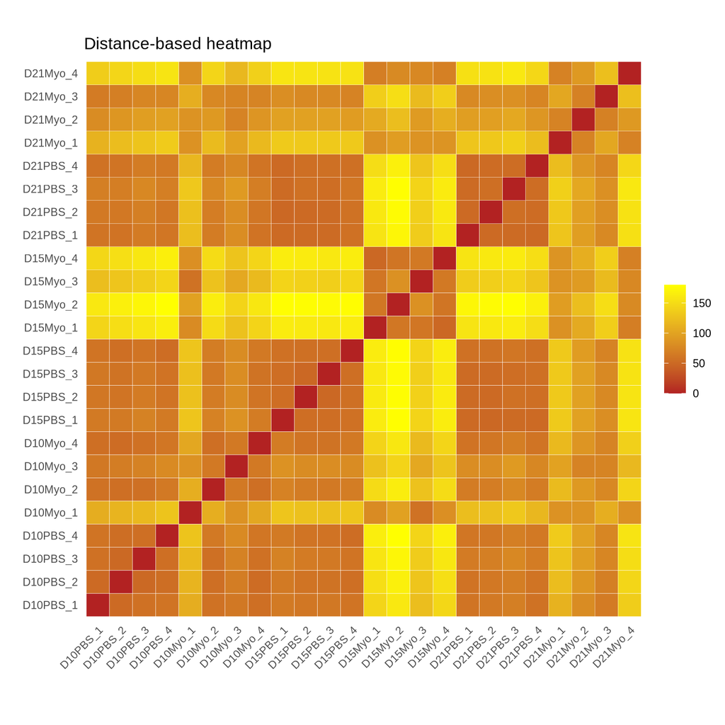

## Distance Dendrogram

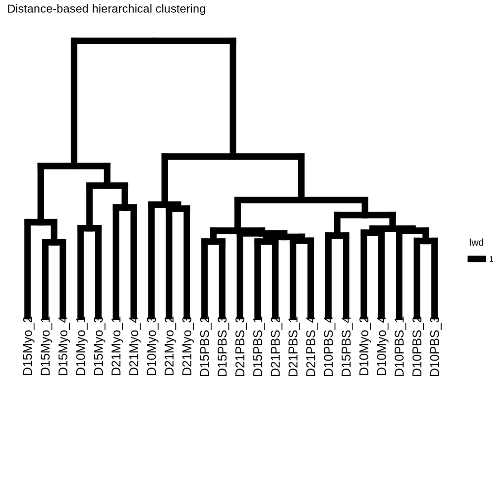

## Spearman’s Rank Heatmap

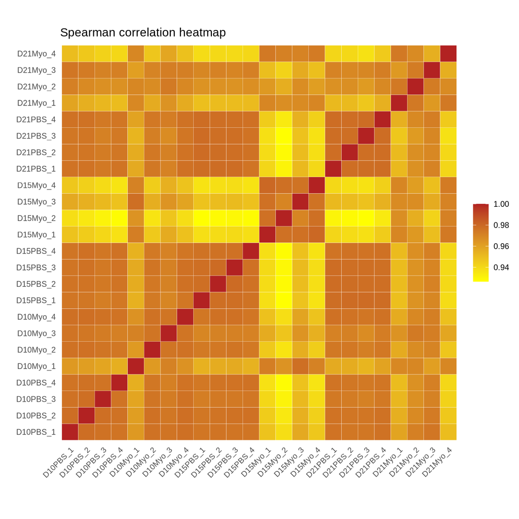

## Spearman’s Rank Dendrogram

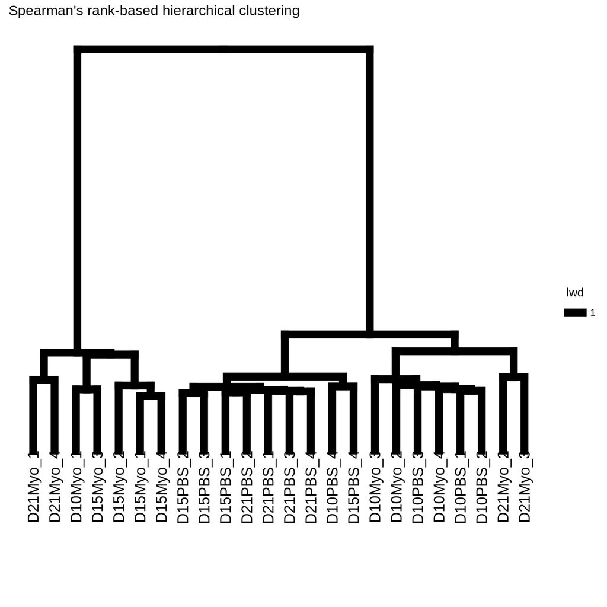

# 7 Principal Components Analysis

PCA aims to simplify the display of high dimensional data set in such a way as to make any clustering immediately apparent. The most significant components are shown here as one of the axes in each plot. Often, only two components are significant and hence only a single plot is required.

The amount of the total variation accounted for by each component is shown.

Ideally each experimental group will be its own cluster, on at least one of these plots.

## 7.1 By Sample Names

Each sample is represented by its name.

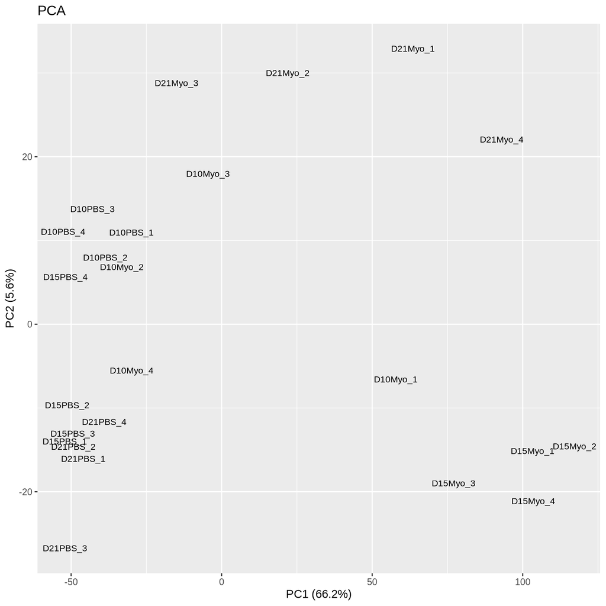

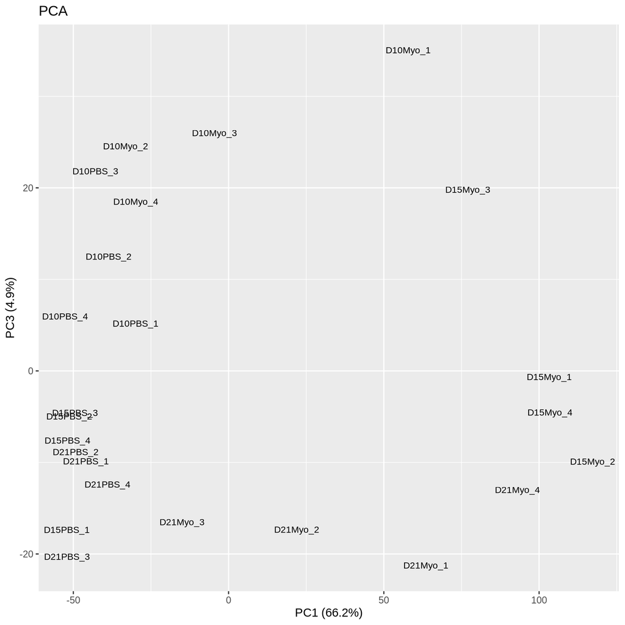

## 7.2 By Groups

Each grouping category is shown separately, if more than one is given. Each dot is one sample.

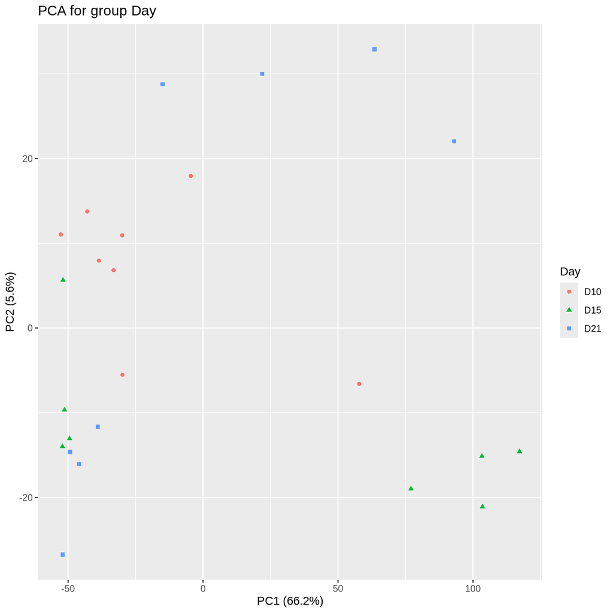

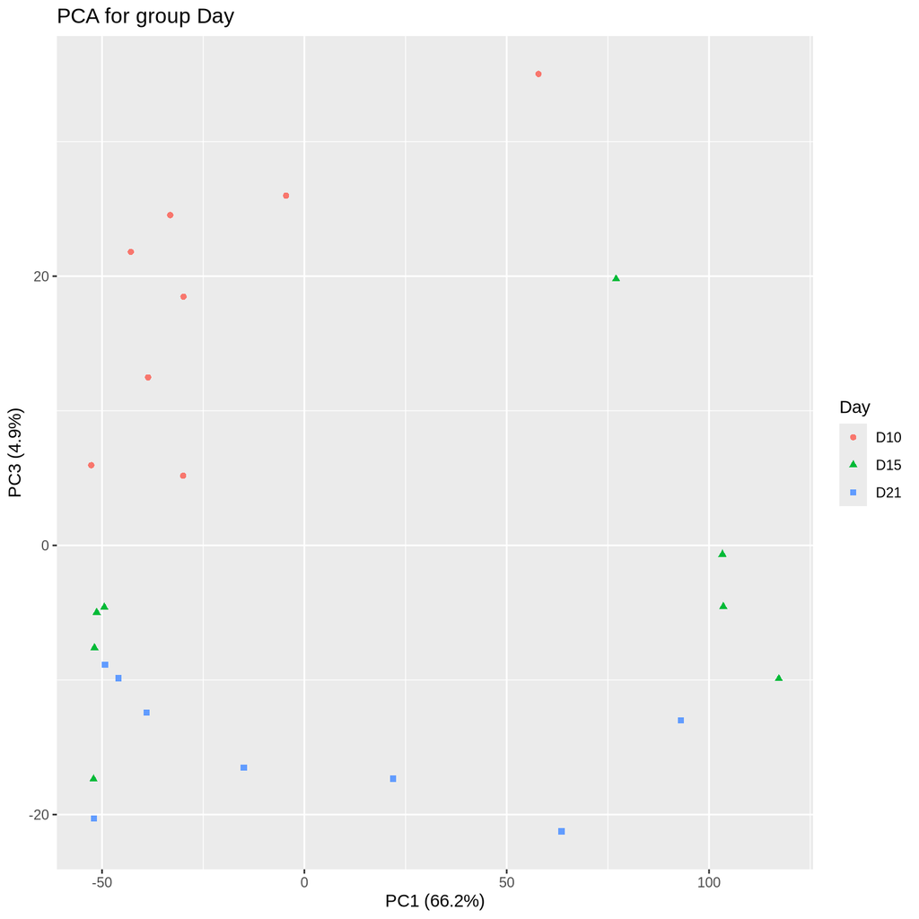

# 8 Additional Metrics

Additional metrics for the dataset, provided by Picard, are plotted here. What constitutes a ‘good’ metric will vary depending on the tissue used and the sequencing protocol. Large disparities between experimental might indicate data quality issues.

Picard is a popular tool for generating these metrics, using [RnaSeqMetrics](https://broadinstitute.github.io/picard/picard-metric-definitions.html) and [MarkDuplicates](https://gatk.broadinstitute.org/hc/en-us/articles/360037052812-MarkDuplicates-Picard).

- All: The number of bases in total.
- Aligned: The number of bases aligned.
- Coding: The number of bases aligned to coding regions.
- UTR: The number of bases aligned to UTRs.
- Intronic: The number of bases aligned to intronic regions.
- Intergenic: The number of bases aligned to intergenic regions.

Coding, UTR, Intronic and Intergenic are subsets of Aligned.

- Median CV Coverage: Median coefficient of variation for the 1000 most highly expressed genes.
- Median 5’ Bias: Of the 1000 most highly expressed genes.
- Median 3’ Bias: Of the 1000 most highly expressed genes.
- Median 5’ to 3’ Bias: The ratio of the two above.
- Duplication Rate: The proportion of reads detected as duplicates. For sequencing methods that sample from only one end of a gene, this is expected to be high.

## Count-based Metrics

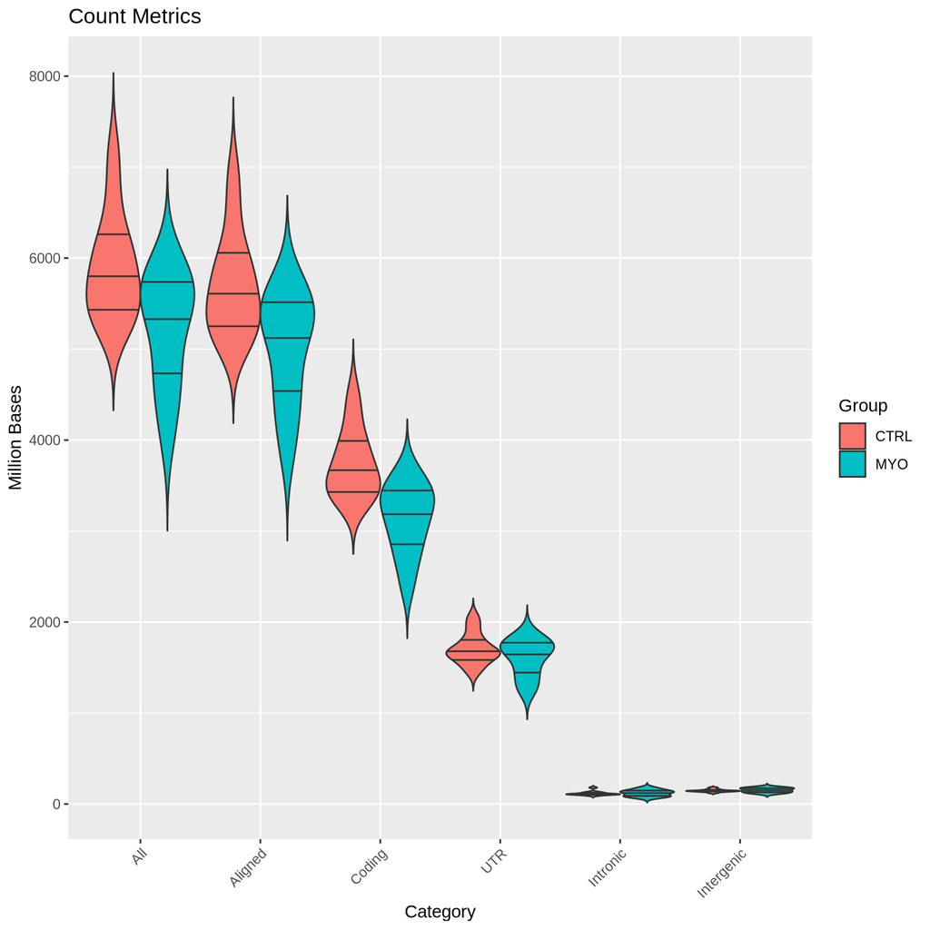

## Proportion-based metrics

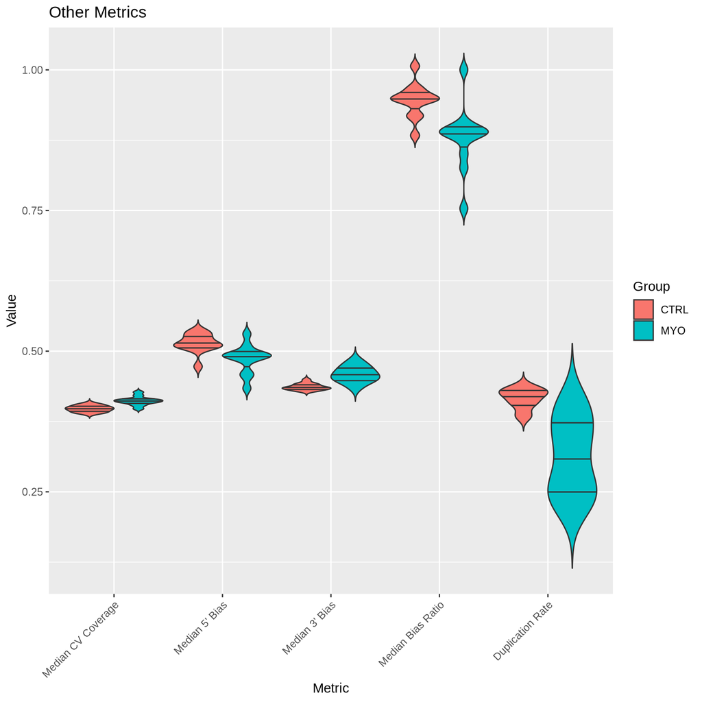

# 9 Tool documentation

- “Picard Toolkit.” 2019. Broad Institute, GitHub Repository. https://broadinstitute.github.io/picard/; Broad Institute
- “R: A language and environment for statistical computing.” 2021. R Core Team https://www.R-project.org/; R Foundation for Statistical Computing, Vienna, Austria.
- Allaire J, Xie Y, McPherson J, Luraschi J, Ushey K, Atkins A, Wickham H, Cheng J, Chang W, Iannone R (2022). “rmarkdown: Dynamic Documents for R” https://github.com/rstudio/rmarkdown
- Galili T (2015). “dendextend: an R package for visualizing, adjusting, and comparing trees of hierarchical clustering.” *Bioinformatics* https://doi.org/10.1093/bioinformatics/btv428
- Huber W, von Heydebreck A, Sueltmann H, Poustka A, Vingron M (2002). “Variance Stabilization Applied to Microarray Data Calibration and to the Quantification of Differential Expression.” *Bioinformatics*, **18 Suppl. 1**, S96-S104.
- Love MI, Huber W, Anders S (2014). “Moderated estimation of fold change and dispersion for RNA-seq data with DESeq2.” *Genome Biology*, **15**, 550. doi: 10.1186/s13059-014-0550-8
- Morgan M, Obenchain V, Hester J, Pagès H (2023). “SummarizedExperiment: SummarizedExperiment container” https://doi.org/10.18129/B9.bioc.SummarizedExperiment
- Wickham H (2007). “Reshaping Data with the reshape Package.” *Journal of Statistical Software*, **21**(12), 1–20. https://www.jstatsoft.org/v21/i12/.
- Wickham H (2016). ggplot2: Elegant Graphics for Data Analysis. Springer-Verlag New York. ISBN 978-3-319-24277-4, https://ggplot2.tidyverse.org.
- Wickham H, Henry L, Pedersen T, Luciani T, Decorde M, Lise V (2023). “svglite: An ‘SVG’ Graphics Device” https://CRAN.R-project.org/package=svglite.
- Xie Y, Allaire J, Grolemund G (2018). R Markdown: The Definitive Guide. Chapman and Hall/CRC, Boca Raton, Florida. ISBN 9781138359338, https://bookdown.org/yihui/rmarkdown.
- Xie Y (2019). “TinyTeX: A lightweight, cross-platform, and easy-to-maintain LaTeX distribution based on TeX Live.” *TUGboat* **40**(1), 30-32. https://tug.org/TUGboat/Contents/contents40-1.html.
- Xie Y, Dervieux C, Riederer E (2020). R Markdown Cookbook. Chapman and Hall/CRC, Boca Raton, Florida. ISBN 9780367563837, https://bookdown.org/yihui/rmarkdown-cookbook.
- Xie Y (2024). “tinytex: Helper Functions to Install and Maintain TeX Live, and Compile LaTeX Documents” https://github.com/rstudio/tinytex.
[^1]: The details can be found in the [DESeq2 documentation](http://bioconductor.org/packages/devel/bioc/vignettes/DESeq2/inst/doc/DESeq2.html).